# DA3 - Assignment 3

Technical Report

Oszkar Egervari

2022-02-18

## Introduction

The goal of this project is to help investors finding companies with a potential for fast growth. To achieve this I built various prediction models on a dataset consisting of companies in the European Union. The data includes all registered companies from 2005-2016 in three selected industries (auto manufacturing, equipment manufacturing, hotels and restaurants). Several features were used during the prediction, such as P/L statements, balance sheets, management information etc. I considered a company fast growing when its compound annual growth rate (CAGR) exceeded 35%. This is an arbitrary number, however after some research I found out that between 15% and 25% CAGR, investors consider a company to be a ‘good investment’ in general, so I wanted to overshoot that value by a bit.

Link to project [Github](https://github.com/oegervari/da3_a3) repo.

## The Data

The data set was constructed by Bisnode, a business data and analytics company (www.bisnode.com) and includes the detailed company data from a middle-sized country in the European Union. All registered companies are from 2005-2016 in three selected industries of auto manufacturing, equipment manufacturing, hotels and restaurants.

The data set has 287 829 observations (46 412 firms) and 48 variables describing all available information like properties of company, balance sheet, profit and loss elements and management information. As mentioned above, the CAGR was calculated to help us decide whether a company qualifies as fast growing.

The analysis is conducted for a period between 2011 and 2013. The CAGR of sales is calculated from 2012 to 2013 and a change of sales variable between 2011 to 2012 was created. In addition log of sales variable was created via applying logarithmic transformation on sales.

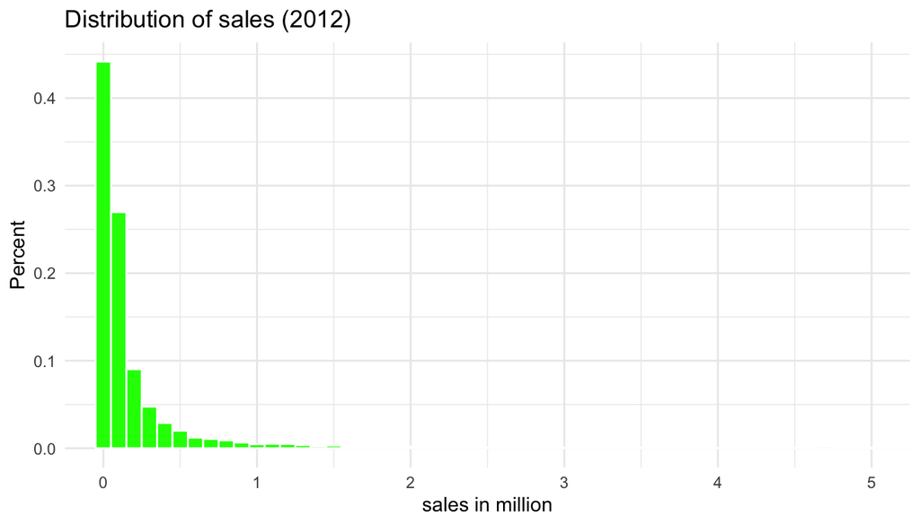

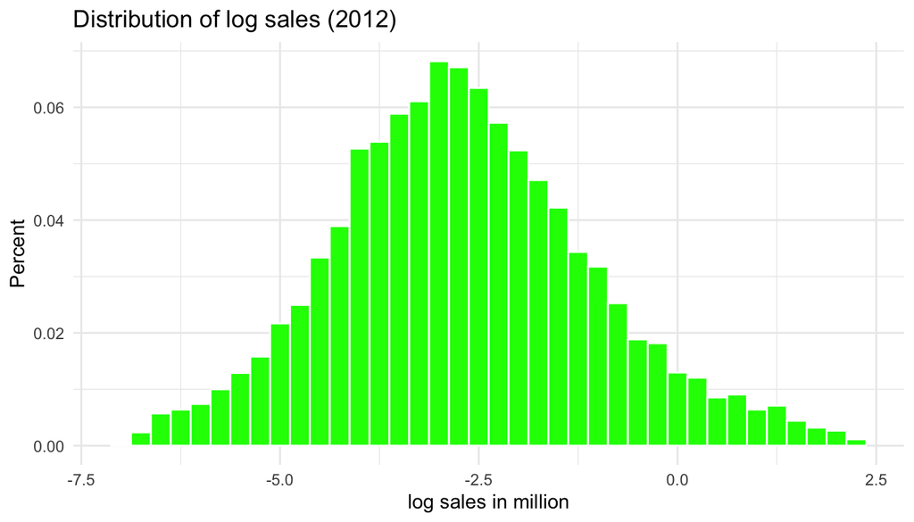

To create a proper analysis we filtered the data for companies with full balance sheet for these 3 years and with a sales number exceeding 0. On top of that, I excluded companies with a sales value (annual) below 1000 and above 10 million Euros. At this point we are left with 59 538 observations. As a last step, the year is set to 2012 and - after creating the cagr_sales variable - companies with cagr_sales values exceeding 5000 or NAs are filtered out, which leaves us with 14 628 observations. The distribution of CAGR of sales can be seen below.

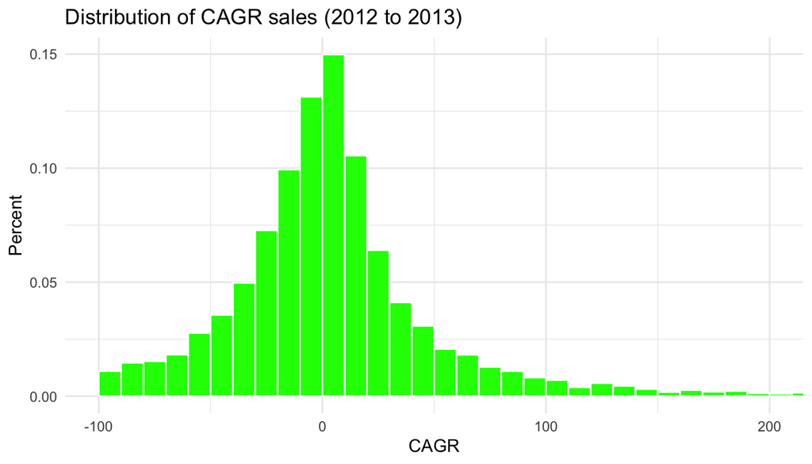

### Feature engineering

During this task I take a look at financial variables and their validity. Variables were flagged with mistakes in their balance sheet (e.g. negative values in assets), also category variables and factors were created. Finally I dropped observations with too many missing values in key variables and we finished with 116 variables and 13 099 observations.

9 groups were created for modelling purposes:

- **Raw variables:** our key variables for the prediction, such as main profit and loss and balance sheet elements.
- **Engine variables 1:** other profit and loss and balance sheet elements.
- **Engine variables 2:** quadratic transformation of some key variables, such as profit and loss, income before tax, extra profit and loss, share of equity. These variables are mostly between -1 and 1.
- **Engine variables 3:** flags of engine 2 variables.
- **D1:** variables measuring change of sales.
- **HR:** data about management such as age and gender of CEO or average labor number.
- **Firm:** properties of the firms, like age of the company, region, etc.
- **Interactions 1 and 2:** interactions of variables.

# Modelling

| fast_growth_f | Number of companies | Percentage |
| --- | --- | --- |
| no_fast_growth | 10703 | 82% |
| fast_growth | 2396 | 18% |

### Splitting the data

The first step before building the models is to split to data to train and holdout sets. The holdout set consists of 20% of the whole set. The selection is random of course. The remaining data is the training set. The holdout set is used for the final evaluation of the models. The training set is again divided into smaller parts with 5-fold cross validation for each model.

### I. Probability logit models

First I build 5 different logit models. Each model contains a different set of variables increasing in complexity, meaning that model 1 is the least complex, while model 5 is the most.

|  | Variables |
| --- | --- |
| X1 model | Log sales + Log sales^2 + Change in Sales + Profit and loss + Industry |
| X2 model | X1 + Fixed assets + Equity + Current liabilities (and flags) + Age + Foreign management |
| X3 model | Log sales + Log sales^2 + Firm + Engine variables 1 + D1 |
| X4 model | X3 + Engine variables 2 + Engine variables 3 + HR |
| X5 model | X4 + Interactions 1 and 2 |

Comparing the models, the two most important measures were the Root Mean Squared Error (RMSE) and the Area Under Curve (AUC), both averaged on the 5 different folds used during cross validation. We can see from the table below that the RMSE and AUC values are really similar for all of the models. The best model that had the lowest RMSE was the third one (X3), but the best model that has the highest AUC was the fourth one (X4). These two models outperformed all the others based on these criterion. I will consider the X3 model as a benchmark as it is simpler with less than half of the predictors the 4th model possesses.

|  | Number.of.predictors | CV.RMSE | CV.AUC |
| --- | --- | --- | --- |
| X1 | 11 | 0.3788 | 0.6394 |
| X2 | 18 | 0.3767 | 0.6574 |
| X3 | 35 | 0.3747 | 0.6771 |
| X4 | 75 | 0.3755 | 0.6781 |
| X5 | 149 | 0.3770 | 0.6720 |

### II. LASSO model

After the basic logit models, by applying LASSO the variables are selected based on calculations, rather than being handpicked. The LASSO model contains all the variables of the 5th logit model. Out of those, only 24 were selected opposed to the 149 predictors of model 5, meanwhile the RMSE slightly improved. However the AUC declined compared to model 3, 4 and 5.

|  | Number.of.predictors | CV.RMSE | CV.AUC |
| --- | --- | --- | --- |
| X3 | 35 | 0.3747 | 0.6771 |
| LASSO | 24 | 0.3748 | 0.6586 |

### III. Random forest

After the logit and LASSO models, I built a random forest model, since it’s good at finding non-linear patterns and interactions. The variables of the fourth model were used without adding polynomials, flag variables etc. In the tuning grid I used the default of growing 500 trees with 10 and 15 as the minimum number of observations at each terminal node, and 5, 6 or 7 variables to use for each split. The random forest outperformed our best model, the X3 logit model, both in terms of lower RMSE with 0.372 and higher AUC with 0.691 values.

|  | CV.RMSE | CV.AUC |
| --- | --- | --- |
| X3 | 0.3747 | 0.6771 |
| Random_forest | 0.3722 | 0.6912 |

### ROC curve

Before finding the best thresholds for our prediction, I drew up the ROC plots for the best models so far, the random forest and the X3 logit model. The threshold values range between 0.05 and 0.75 with an increment of 0.025. This shows us how the increasing threshold leads to lower True positive and False positive rates. The second plot shows the Area Under the Curve. There is a trade off between accurate true positive and true negative predictions. Setting up the loss function helps us find the optimal threshold.

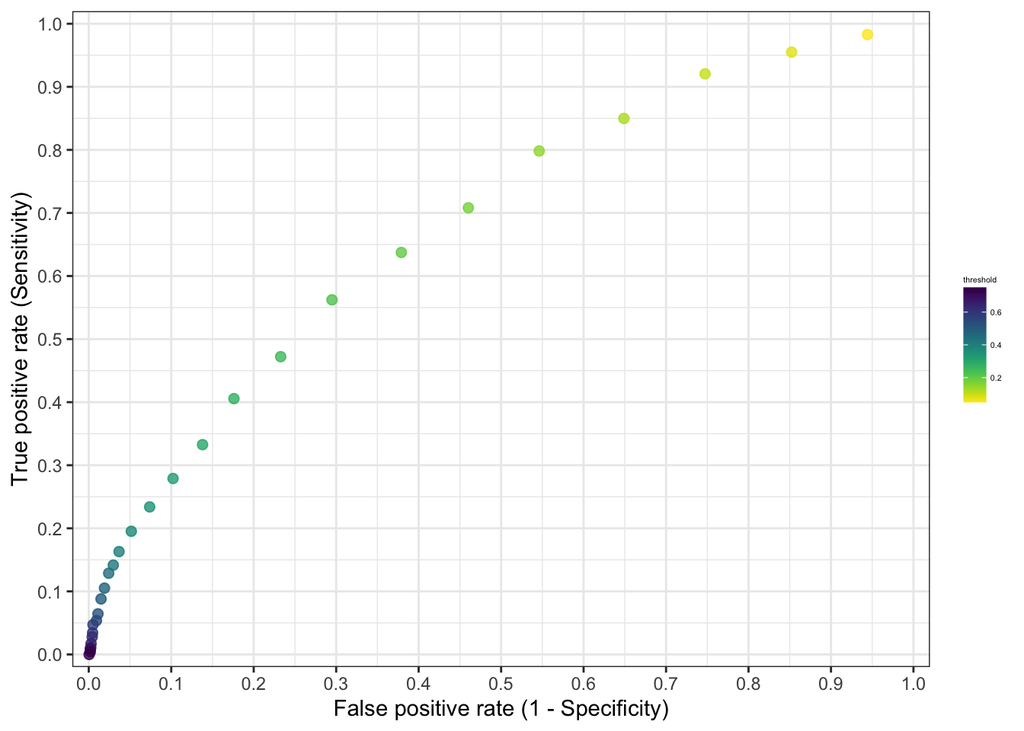

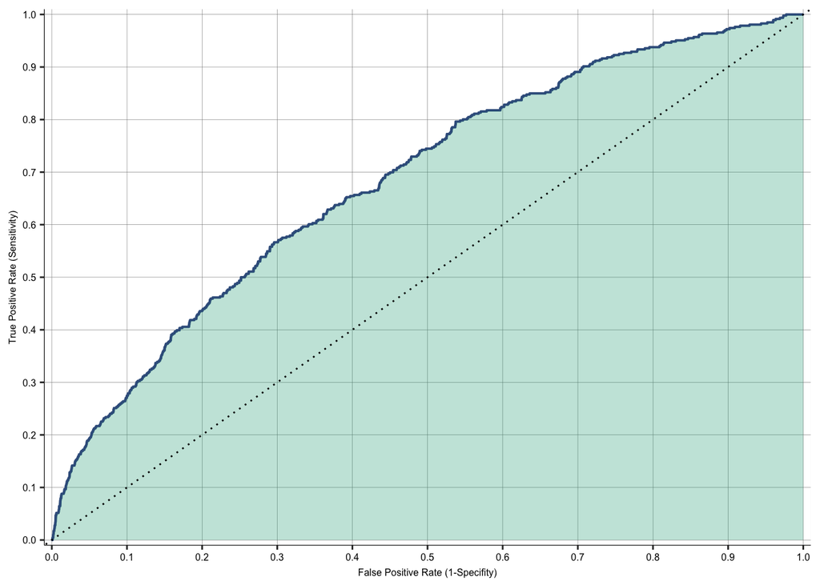

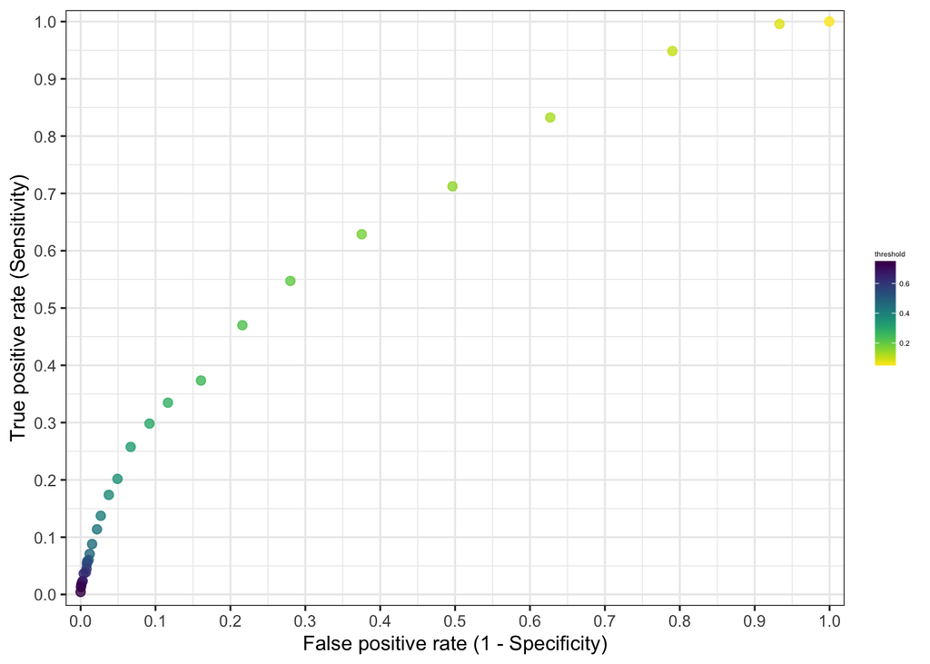

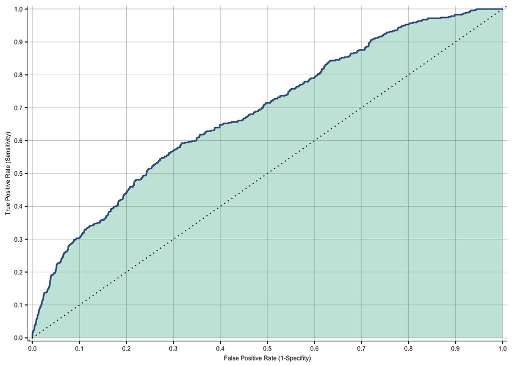

### Finding the optimal threshold

To find the optimal threshold, we have to weigh the consequences of a false negative and a false positive prediction. In case of a false positive prediction, one would make a bad investment. It can mean acquiring less return compared to an alternative investment, but also potentially losing money. On the other hand, a false negative prediction would would result in loosing out on a good investment. Considering all this, my personal opinion is that a false positive prediction has less downside, than a false negative, so I set the loss function to a 1/2 FP/FN ratio, meaning that a false negative prediction costs twice as much as a false positive.

|  | Number.of.predictors | CV.RMSE | CV.AUC | CV.threshold | CV.expected.Loss |
| --- | --- | --- | --- | --- | --- |
| Logit X1 | 11 | 0.3788 | 0.6394 | 0.3480 | 0.3505 |
| Logit X3 | 35 | 0.3747 | 0.6771 | 0.3507 | 0.3392 |
| Logit X4 | 75 | 0.3755 | 0.6781 | 0.3499 | 0.3435 |
| Logit LASSO | 24 | 0.3748 | 0.6586 | 0.3413 | 0.3517 |
| RF probability | 33 | 0.3722 | 0.6912 | 0.3514 | 0.3347 |

### Model evaluation

|  | no_fast_growth | fast_growth |
| --- | --- | --- |
| no_fast_growth | 2047 | 373 |
| fast_growth | 106 | 93 |

| model | Test.RMSE | Test.AUC | Avg..Exp..Loss |
| --- | --- | --- | --- |
| X3 Logit Model | 0.3674 | 0.6834 | 0.3249 |